# ADVERSARIAL ATTACK

## Introduction

- Reliability
- Robustness to *adversarial examples*
  - Perturbations of their inputs, intending to fool the classifier
  - Vulnerability to imperceptible variations crafted to mislead the models

[figure not shown]

- How...
  - ...are these pertubations crafted?
  - ...can we create robust classifier?

## Creating an adversarial example

- Adjust image to *maximize* loss ISO $\theta$ with the gradient $\nabla_\theta \ell(h_\theta(x_i), y_i)$
  - Solve the optimization problem \begin{equation} \DeclareMathOperator*{\maximize}{maximize} \maximize_{\hat{x}} \ell(h_\theta(\hat{x}), y) \end{equation} where $\hat{x}$ denotes our adversarial example attempting to maximize the loss.
  - Ensure that $\hat{x}$ is close to our original input $x$
  - By convention, optimizing over the *perturbation* $\delta$ to $x$ \begin{equation} \maximize_{\delta \in \Delta} \ell(h_\theta(x +\delta), y) \end{equation} with $\Delta$ a set of perturbations (that makes $x + \tau$ sufficiently close to $x$)
- Characterizing the "correct" set of allowable perturbations:
  - $\Delta$: anything that humans visually feel to be the "same" as $x$
  - reasonable choice, is the $\ell_\infty$ ball, defined by the set \begin{equation} \Delta = \{\delta : \|\delta\|_\infty \leq \epsilon\} \end{equation} where the $\ell_\infty$ norm a vector $z$ is defined as \begin{equation} \|z\|_\infty = \max_i |z_i| \end{equation}
  - allow perturbation to have magnitude $[-\epsilon, \epsilon]$ in each of its components
  - (ensure that $x + \delta$ is $[0,1]$ bounded so that it is still a valid image)

## Binary classification

Simplified problem where $h_\theta$ is a linear classifier and k=2 (binary classification)

Binary cross entropy (logistic loss) iso multi-class cross entropy loss

- hypothesis function \begin{equation} h_\theta(x) = w^T x + b \end{equation} for $\theta = \{w \in \mathbb{R}^n, b \in \mathbb{R}\}$,
- class label $y \in \{+1,-1\}$, and
- loss function \begin{equation} \ell(h_\theta(x), y) = \log(1+\exp(-y\cdot h_\theta(x))) \equiv L(y \cdot h_\theta(x)) \end{equation} where for convinience we define $L(z) = \log(1+\exp(-z))$.
- For a data point $x$, the classifier predicts class $+1$ with probability \begin{equation} p(y=+1|x) = \frac{1}{1 + \exp(-h_\theta(x))} \end{equation}

### Computing an Adversarial pertubation

- Adversarial example in the context of binary classification: \begin{equation} \DeclareMathOperator*{\maximize}{maximize} \maximize_{\|\delta\| \leq \epsilon} \ell(w^T (x+\delta), y) \equiv \maximize_{\|\delta\| \leq \epsilon} L(y \cdot (w^T(x+\delta) + b)). \end{equation}
- Solve this maximization problem exactly:
  - function monotonic decreasing hence
  - maximize function applied to a scalar: minimizing the scalar quantity
  - \begin{equation} \begin{split} \DeclareMathOperator*{\minimize}{minimize} \max_{\|\delta\| \leq \epsilon} L \left(y \cdot (w^T(x+\delta) + b) \right) & = L\left( \min_{\|\delta\| \leq \epsilon} y \cdot (w^T(x+\delta) + b) \right) \\ & = L\left(y\cdot(w^Tx + b) + \min_{\|\delta\| \leq \epsilon} y \cdot w^T\delta \right) \end{split} \end{equation}, by distributing out the linear terms, hence
  - solve \begin{equation} \min_{\|\delta\| \leq \epsilon} y \cdot w^T\delta. \end{equation}
- Case that $y = +1$, and consider an $\ell_\infty$ norm constraint $\|\delta\|_\infty \leq \epsilon$
  - Minimizing this quantity: sets $\delta_i = -\epsilon$ for $w_i \geq 0$ and $\delta_i = \epsilon$ for $w_i < 0$
  - For $y = -1$, we would just flip these quantities
  - optimal solution to the above optimization problem for the $\ell_\infty$ norm is \begin{equation} \delta^\star = - y \epsilon \cdot \mathrm{sign}(w) \end{equation}

### How well traditional linear models might work against adversarial examples?

1. Define and train with gradient descent a linear model using the PyTorch and MNIST
2. Evaluate the model on the train and test dataset
3. Test set
   1. Create adversarial pertubation on the images of the test set and
   2. Evaluate the performance of your model *under attack*
4. Evaluate visibility of the pertubation, ploting original next to adversarial image
5. Make a small analysis and conclusion

#### Define and train with gradient descent a linear model

```python
# Define the model
class Model(torch.nn.Module): # Base class for all neural network modules

  def __init__(self):
    super(Model, self).__init__()
# Applies a linear transformation to the incoming data: y = xA^T + b
    self.linear = torch.nn.Linear(
        input_dim, output_dim)

  def forward(self, x):

    outputs = self.linear(x)
    return outputs


model = Model()
```

```python
# evalutation on test set
accuracy = 0.
n_inputs = 0.
correct = 0.
for n_batch, (imgs, labels) in enumerate(test_loader):
  n_inputs+=imgs.shape[0]

  outputs=model(imgs.view(-1,784))[:,0]
  # check if the Outputs "match" the Labels
  outputs = (outputs>0).float()
  correct+= (outputs == labels).float().sum()
print(correct/n_inputs)
```

```
tensor(0.9987)
```

#### Adversarial pertubation on the test set and evaluate the performance of the model *under attack*

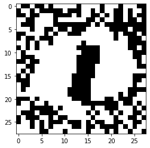

```python
# compute and plot the adversairal pertubation
eps = 0.2
delta = eps * model.linear.weight.detach().sign()
plt.imshow(1-delta.reshape(28, 28), cmap="gray")
plt.show()
```

```python
accuracy = 0.
n_inputs = 0.
correct = 0.
for n_batch, (imgs, labels) in enumerate(test_loader):
  n_inputs+=imgs.shape[0]

  outputs=model(imgs.view(-1,784)-(2*labels.view(-1,1)-1)*delta)[:,0]
  # check if the Outputs "match" the Labels
  outputs = (outputs>0).float()
  correct+= (outputs == labels).float().sum()
print(correct/n_inputs)
```

```
tensor(0.3582)
```

#### Evaluate the visibility of the pertubation

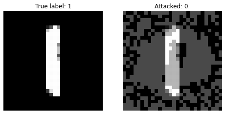

#### Attack analysis and Conclusion

Traditional linear models don't work to prevent adversarial examples.